From: https://github.com/ksatola

# Sonar - Mines vs. Rocks

The task is to discriminate between sonar signals bounced off a metal cylinder and those bounced off a roughly cylindrical rock. Or simply predict metal or rock objects from sonar return data.

The data set was contributed to the benchmark collection by Terry Sejnowski, now at the Salk Institute and the University of California at San Deigo. The data set was developed in collaboration with R. Paul Gorman of Allied-Signal Aerospace Technology Center.

Downloaded from: https://archive.ics.uci.edu/ml/datasets/Connectionist+Bench+(Sonar,+Mines+vs.+Rocks)

## Dataset

The file "sonar.mines" contains 111 patterns obtained by bouncing sonar signals off a metal cylinder at various angles and under various conditions. The file "sonar.rocks" contains 97 patterns obtained from rocks under similar conditions. The transmitted sonar signal is a frequency-modulated chirp, rising in frequency. The data set contains signals obtained from a variety of different aspect angles, spanning 90 degrees for the cylinder and 180 degrees for the rock.

Each pattern is a set of 60 numbers in the range 0.0 to 1.0. Each number represents the energy within a particular frequency band, integrated over a certain period of time. The integration aperture for higher frequencies occur later in time, since these frequencies are transmitted later during the chirp.

The label associated with each record contains the letter "R" if the object is a rock and "M" if it is a mine (metal cylinder). The numbers in the labels are in increasing order of aspect angle, but they do not encode the angle directly.

# Imports

```python
# Load libraries
import numpy as np
import pandas as pd
from pandas.plotting import scatter_matrix
import matplotlib.pyplot as plt

from pickle import dump
from pickle import load

from sklearn.preprocessing import StandardScaler
from sklearn.model_selection import train_test_split
from sklearn.model_selection import KFold
from sklearn.model_selection import cross_val_score
from sklearn.model_selection import GridSearchCV

from sklearn.linear_model import LogisticRegression
from sklearn.tree import DecisionTreeClassifier
from sklearn.neighbors import KNeighborsClassifier
from sklearn.discriminant_analysis import LinearDiscriminantAnalysis
from sklearn.naive_bayes import GaussianNB
from sklearn.svm import SVC

from sklearn.pipeline import Pipeline
from sklearn.ensemble import AdaBoostClassifier
from sklearn.ensemble import GradientBoostingClassifier
from sklearn.ensemble import RandomForestClassifier
from sklearn.ensemble import ExtraTreesClassifier

from sklearn.metrics import classification_report
from sklearn.metrics import confusion_matrix
from sklearn.metrics import accuracy_score

from numpy import set_printoptions
pd.set_option('display.width', 100)
pd.set_option('precision', 5)

%matplotlib inline
```

# Load the dataset

```python
# Load dataset
filename = 'sonar.all-data'
df = pd.read_csv(filename, header=None)
```

We are not specifying the names of the attributes. This is because other than the class attribute (the last column), the variables do not have meaningful names. We also indicate that there is no header information, this is to avoid file loading code taking the first record as the column names.

# Sumarize the dataset

```python
# Dimensions of the dataset
df.shape
```

```
(208, 61)
```

There are 208 observations and 61 attributes.

```python
# Peek at the data itself
#df.head(20)
df.sample(10)
```

|  | 0 | 1 | 2 | 3 | 4 | 5 | 6 | 7 | 8 | 9 | ... | 51 | 52 | 53 | 54 | 55 | 56 | 57 | 58 | 59 | 60 |
| --- | --- | --- | --- | --- | --- | --- | --- | --- | --- | --- | --- | --- | --- | --- | --- | --- | --- | --- | --- | --- | --- |
| 138 | 0.0731 | 0.1249 | 0.1665 | 0.1496 | 0.1443 | 0.2770 | 0.2555 | 0.1712 | 0.0466 | 0.1114 | ... | 0.0444 | 0.0230 | 0.0290 | 0.0141 | 0.0161 | 0.0177 | 0.0194 | 0.0207 | 0.0057 | M |
| 87 | 0.0856 | 0.0454 | 0.0382 | 0.0203 | 0.0385 | 0.0534 | 0.2140 | 0.3110 | 0.2837 | 0.2751 | ... | 0.0172 | 0.0138 | 0.0079 | 0.0037 | 0.0051 | 0.0258 | 0.0102 | 0.0037 | 0.0037 | R |
| 101 | 0.0335 | 0.0134 | 0.0696 | 0.1180 | 0.0348 | 0.1180 | 0.1948 | 0.1607 | 0.3036 | 0.4372 | ... | 0.0244 | 0.0232 | 0.0093 | 0.0159 | 0.0193 | 0.0032 | 0.0377 | 0.0126 | 0.0156 | M |
| 190 | 0.0156 | 0.0210 | 0.0282 | 0.0596 | 0.0462 | 0.0779 | 0.1365 | 0.0780 | 0.1038 | 0.1567 | ... | 0.0150 | 0.0060 | 0.0082 | 0.0091 | 0.0038 | 0.0056 | 0.0056 | 0.0048 | 0.0024 | M |
| 133 | 0.0790 | 0.0707 | 0.0352 | 0.1660 | 0.1330 | 0.0226 | 0.0771 | 0.2678 | 0.5664 | 0.6609 | ... | 0.0298 | 0.0390 | 0.0294 | 0.0175 | 0.0249 | 0.0141 | 0.0073 | 0.0025 | 0.0101 | M |
| 51 | 0.0131 | 0.0068 | 0.0308 | 0.0311 | 0.0085 | 0.0767 | 0.0771 | 0.0640 | 0.0726 | 0.0901 | ... | 0.0062 | 0.0028 | 0.0040 | 0.0075 | 0.0039 | 0.0053 | 0.0013 | 0.0052 | 0.0023 | R |
| 1 | 0.0453 | 0.0523 | 0.0843 | 0.0689 | 0.1183 | 0.2583 | 0.2156 | 0.3481 | 0.3337 | 0.2872 | ... | 0.0084 | 0.0089 | 0.0048 | 0.0094 | 0.0191 | 0.0140 | 0.0049 | 0.0052 | 0.0044 | R |
| 97 | 0.0491 | 0.0279 | 0.0592 | 0.1270 | 0.1772 | 0.1908 | 0.2217 | 0.0768 | 0.1246 | 0.2028 | ... | 0.0081 | 0.0129 | 0.0161 | 0.0063 | 0.0119 | 0.0194 | 0.0140 | 0.0332 | 0.0439 | M |
| 112 | 0.0454 | 0.0472 | 0.0697 | 0.1021 | 0.1397 | 0.1493 | 0.1487 | 0.0771 | 0.1171 | 0.1675 | ... | 0.0120 | 0.0042 | 0.0238 | 0.0129 | 0.0084 | 0.0218 | 0.0321 | 0.0154 | 0.0053 | M |
| 179 | 0.0394 | 0.0420 | 0.0446 | 0.0551 | 0.0597 | 0.1416 | 0.0956 | 0.0802 | 0.1618 | 0.2558 | ... | 0.0146 | 0.0040 | 0.0114 | 0.0032 | 0.0062 | 0.0101 | 0.0068 | 0.0053 | 0.0087 | M |

10 rows × 61 columns

This does not show all of the columns, but we can see all of the data has the same scale. We can also see that the class attribute (60) has string values.

```python
df.info()
```

```
<class 'pandas.core.frame.DataFrame'>
RangeIndex: 208 entries, 0 to 207
Data columns (total 61 columns):
0     208 non-null float64
1     208 non-null float64
2     208 non-null float64
3     208 non-null float64
4     208 non-null float64
5     208 non-null float64
6     208 non-null float64
7     208 non-null float64
8     208 non-null float64
9     208 non-null float64
10    208 non-null float64
11    208 non-null float64
```

[output cut: 51 more lines]

We can see that all of the attributes are numeric (float) and that the class value has been read in as an object.

```python
# Are there any missing values?
df.isnull().values.any()
```

```
False
```

```python
df.describe().T
```

|  | count | mean | std | min | 25% | 50% | 75% | max |
| --- | --- | --- | --- | --- | --- | --- | --- | --- |
| 0 | 208.0 | 0.02916 | 0.02299 | 0.0015 | 0.01335 | 0.02280 | 0.03555 | 0.1371 |
| 1 | 208.0 | 0.03844 | 0.03296 | 0.0006 | 0.01645 | 0.03080 | 0.04795 | 0.2339 |
| 2 | 208.0 | 0.04383 | 0.03843 | 0.0015 | 0.01895 | 0.03430 | 0.05795 | 0.3059 |
| 3 | 208.0 | 0.05389 | 0.04653 | 0.0058 | 0.02438 | 0.04405 | 0.06450 | 0.4264 |
| 4 | 208.0 | 0.07520 | 0.05555 | 0.0067 | 0.03805 | 0.06250 | 0.10028 | 0.4010 |
| 5 | 208.0 | 0.10457 | 0.05911 | 0.0102 | 0.06703 | 0.09215 | 0.13412 | 0.3823 |
| 6 | 208.0 | 0.12175 | 0.06179 | 0.0033 | 0.08090 | 0.10695 | 0.15400 | 0.3729 |
| 7 | 208.0 | 0.13480 | 0.08515 | 0.0055 | 0.08042 | 0.11210 | 0.16960 | 0.4590 |
| 8 | 208.0 | 0.17800 | 0.11839 | 0.0075 | 0.09703 | 0.15225 | 0.23342 | 0.6828 |
| 9 | 208.0 | 0.20826 | 0.13442 | 0.0113 | 0.11127 | 0.18240 | 0.26870 | 0.7106 |
| 10 | 208.0 | 0.23601 | 0.13270 | 0.0289 | 0.12925 | 0.22480 | 0.30165 | 0.7342 |
| 11 | 208.0 | 0.25022 | 0.14007 | 0.0236 | 0.13348 | 0.24905 | 0.33125 | 0.7060 |
| 12 | 208.0 | 0.27331 | 0.14096 | 0.0184 | 0.16613 | 0.26395 | 0.35125 | 0.7131 |
| 13 | 208.0 | 0.29657 | 0.16447 | 0.0273 | 0.17517 | 0.28110 | 0.38618 | 0.9970 |
| 14 | 208.0 | 0.32020 | 0.20543 | 0.0031 | 0.16462 | 0.28170 | 0.45293 | 1.0000 |
| 15 | 208.0 | 0.37849 | 0.23265 | 0.0162 | 0.19630 | 0.30470 | 0.53573 | 0.9988 |
| 16 | 208.0 | 0.41598 | 0.26368 | 0.0349 | 0.20585 | 0.30840 | 0.65943 | 1.0000 |
| 17 | 208.0 | 0.45232 | 0.26153 | 0.0375 | 0.24208 | 0.36830 | 0.67905 | 1.0000 |
| 18 | 208.0 | 0.50481 | 0.25799 | 0.0494 | 0.29907 | 0.43495 | 0.73140 | 1.0000 |
| 19 | 208.0 | 0.56305 | 0.26265 | 0.0656 | 0.35063 | 0.54250 | 0.80932 | 1.0000 |
| 20 | 208.0 | 0.60906 | 0.25782 | 0.0512 | 0.39972 | 0.61770 | 0.81698 | 1.0000 |
| 21 | 208.0 | 0.62428 | 0.25588 | 0.0219 | 0.40692 | 0.66490 | 0.83198 | 1.0000 |
| 22 | 208.0 | 0.64698 | 0.25018 | 0.0563 | 0.45023 | 0.69970 | 0.84857 | 1.0000 |
| 23 | 208.0 | 0.67265 | 0.23912 | 0.0239 | 0.54073 | 0.69850 | 0.87218 | 1.0000 |
| 24 | 208.0 | 0.67542 | 0.24493 | 0.0240 | 0.52580 | 0.72110 | 0.87372 | 1.0000 |
| 25 | 208.0 | 0.69987 | 0.23723 | 0.0921 | 0.54417 | 0.75450 | 0.89380 | 1.0000 |
| 26 | 208.0 | 0.70215 | 0.24566 | 0.0481 | 0.53190 | 0.74560 | 0.91710 | 1.0000 |
| 27 | 208.0 | 0.69402 | 0.23719 | 0.0284 | 0.53478 | 0.73190 | 0.90028 | 1.0000 |
| 28 | 208.0 | 0.64207 | 0.24025 | 0.0144 | 0.46370 | 0.68080 | 0.85213 | 1.0000 |
| 29 | 208.0 | 0.58093 | 0.22075 | 0.0613 | 0.41140 | 0.60715 | 0.73518 | 1.0000 |
| 30 | 208.0 | 0.50448 | 0.21399 | 0.0482 | 0.34555 | 0.49035 | 0.64195 | 0.9657 |
| 31 | 208.0 | 0.43904 | 0.21324 | 0.0404 | 0.28140 | 0.42960 | 0.58030 | 0.9306 |
| 32 | 208.0 | 0.41722 | 0.20651 | 0.0477 | 0.25788 | 0.39120 | 0.55612 | 1.0000 |
| 33 | 208.0 | 0.40323 | 0.23124 | 0.0212 | 0.21757 | 0.35105 | 0.59613 | 0.9647 |
| 34 | 208.0 | 0.39257 | 0.25913 | 0.0223 | 0.17938 | 0.31275 | 0.59335 | 1.0000 |
| 35 | 208.0 | 0.38485 | 0.26412 | 0.0080 | 0.15435 | 0.32115 | 0.55652 | 1.0000 |
| 36 | 208.0 | 0.36381 | 0.23991 | 0.0351 | 0.16010 | 0.30630 | 0.51890 | 0.9497 |
| 37 | 208.0 | 0.33966 | 0.21297 | 0.0383 | 0.17428 | 0.31270 | 0.44055 | 1.0000 |
| 38 | 208.0 | 0.32580 | 0.19907 | 0.0371 | 0.17397 | 0.28350 | 0.43490 | 0.9857 |
| 39 | 208.0 | 0.31121 | 0.17866 | 0.0117 | 0.18645 | 0.27805 | 0.42435 | 0.9297 |
| 40 | 208.0 | 0.28925 | 0.17111 | 0.0360 | 0.16310 | 0.25950 | 0.38753 | 0.8995 |
| 41 | 208.0 | 0.27829 | 0.16873 | 0.0056 | 0.15890 | 0.24510 | 0.38425 | 0.8246 |
| 42 | 208.0 | 0.24654 | 0.13899 | 0.0000 | 0.15520 | 0.22255 | 0.32453 | 0.7733 |
| 43 | 208.0 | 0.21408 | 0.13329 | 0.0000 | 0.12688 | 0.17770 | 0.27175 | 0.7762 |
| 44 | 208.0 | 0.19723 | 0.15163 | 0.0000 | 0.09447 | 0.14800 | 0.23155 | 0.7034 |
| 45 | 208.0 | 0.16063 | 0.13394 | 0.0000 | 0.06855 | 0.12135 | 0.20038 | 0.7292 |
| 46 | 208.0 | 0.12245 | 0.08695 | 0.0000 | 0.06425 | 0.10165 | 0.15442 | 0.5522 |
| 47 | 208.0 | 0.09142 | 0.06242 | 0.0000 | 0.04512 | 0.07810 | 0.12010 | 0.3339 |
| 48 | 208.0 | 0.05193 | 0.03595 | 0.0000 | 0.02635 | 0.04470 | 0.06853 | 0.1981 |
| 49 | 208.0 | 0.02042 | 0.01367 | 0.0000 | 0.01155 | 0.01790 | 0.02528 | 0.0825 |
| 50 | 208.0 | 0.01607 | 0.01201 | 0.0000 | 0.00843 | 0.01390 | 0.02082 | 0.1004 |
| 51 | 208.0 | 0.01342 | 0.00963 | 0.0008 | 0.00728 | 0.01140 | 0.01673 | 0.0709 |
| 52 | 208.0 | 0.01071 | 0.00706 | 0.0005 | 0.00508 | 0.00955 | 0.01490 | 0.0390 |
| 53 | 208.0 | 0.01094 | 0.00730 | 0.0010 | 0.00537 | 0.00930 | 0.01450 | 0.0352 |
| 54 | 208.0 | 0.00929 | 0.00709 | 0.0006 | 0.00415 | 0.00750 | 0.01210 | 0.0447 |
| 55 | 208.0 | 0.00822 | 0.00574 | 0.0004 | 0.00440 | 0.00685 | 0.01058 | 0.0394 |
| 56 | 208.0 | 0.00782 | 0.00579 | 0.0003 | 0.00370 | 0.00595 | 0.01043 | 0.0355 |
| 57 | 208.0 | 0.00795 | 0.00647 | 0.0003 | 0.00360 | 0.00580 | 0.01035 | 0.0440 |
| 58 | 208.0 | 0.00794 | 0.00618 | 0.0001 | 0.00368 | 0.00640 | 0.01033 | 0.0364 |
| 59 | 208.0 | 0.00651 | 0.00503 | 0.0006 | 0.00310 | 0.00530 | 0.00853 | 0.0439 |

The data has the same range, but interestingly differing mean values. There may be some benefit from standardizing the data.

```python
# Breakdown of the data by the class variable (60)
df.groupby(60).size()
```

```
60
M    111
R     97
dtype: int64
```

```python
# Encode M and R with 1 and 0 (required by the StandardScaler method - see Standardization section below)
df[60].replace('M', 1, inplace=True)
df[60].replace('R', 0, inplace=True)
```

```python
# Check
df.sample(10)
```

|  | 0 | 1 | 2 | 3 | 4 | 5 | 6 | 7 | 8 | 9 | ... | 51 | 52 | 53 | 54 | 55 | 56 | 57 | 58 | 59 | 60 |
| --- | --- | --- | --- | --- | --- | --- | --- | --- | --- | --- | --- | --- | --- | --- | --- | --- | --- | --- | --- | --- | --- |
| 30 | 0.0240 | 0.0218 | 0.0324 | 0.0569 | 0.0330 | 0.0513 | 0.0897 | 0.0713 | 0.0569 | 0.0389 | ... | 0.0162 | 0.0146 | 0.0093 | 0.0112 | 0.0094 | 0.0054 | 0.0019 | 0.0066 | 0.0023 | 0 |
| 88 | 0.0274 | 0.0242 | 0.0621 | 0.0560 | 0.1129 | 0.0973 | 0.1823 | 0.1745 | 0.1440 | 0.1808 | ... | 0.0113 | 0.0108 | 0.0085 | 0.0047 | 0.0074 | 0.0104 | 0.0161 | 0.0220 | 0.0173 | 0 |
| 132 | 0.0968 | 0.0821 | 0.0629 | 0.0608 | 0.0617 | 0.1207 | 0.0944 | 0.4223 | 0.5744 | 0.5025 | ... | 0.0073 | 0.0081 | 0.0303 | 0.0190 | 0.0212 | 0.0126 | 0.0201 | 0.0210 | 0.0041 | 1 |
| 81 | 0.0100 | 0.0194 | 0.0155 | 0.0489 | 0.0839 | 0.1009 | 0.1627 | 0.2071 | 0.2696 | 0.2990 | ... | 0.0130 | 0.0073 | 0.0077 | 0.0075 | 0.0060 | 0.0080 | 0.0019 | 0.0053 | 0.0019 | 0 |
| 197 | 0.0366 | 0.0421 | 0.0504 | 0.0250 | 0.0596 | 0.0252 | 0.0958 | 0.0991 | 0.1419 | 0.1847 | ... | 0.0132 | 0.0027 | 0.0022 | 0.0059 | 0.0016 | 0.0025 | 0.0017 | 0.0027 | 0.0027 | 1 |
| 22 | 0.0099 | 0.0484 | 0.0299 | 0.0297 | 0.0652 | 0.1077 | 0.2363 | 0.2385 | 0.0075 | 0.1882 | ... | 0.0173 | 0.0149 | 0.0115 | 0.0202 | 0.0139 | 0.0029 | 0.0160 | 0.0106 | 0.0134 | 0 |
| 95 | 0.0291 | 0.0400 | 0.0771 | 0.0809 | 0.0521 | 0.1051 | 0.0145 | 0.0674 | 0.1294 | 0.1146 | ... | 0.0056 | 0.0237 | 0.0204 | 0.0050 | 0.0137 | 0.0164 | 0.0081 | 0.0139 | 0.0111 | 0 |
| 154 | 0.0117 | 0.0069 | 0.0279 | 0.0583 | 0.0915 | 0.1267 | 0.1577 | 0.1927 | 0.2361 | 0.2169 | ... | 0.0053 | 0.0029 | 0.0020 | 0.0013 | 0.0029 | 0.0020 | 0.0062 | 0.0026 | 0.0052 | 1 |
| 79 | 0.0108 | 0.0086 | 0.0058 | 0.0460 | 0.0752 | 0.0887 | 0.1015 | 0.0494 | 0.0472 | 0.0393 | ... | 0.0029 | 0.0078 | 0.0114 | 0.0083 | 0.0058 | 0.0003 | 0.0023 | 0.0026 | 0.0027 | 0 |
| 147 | 0.0654 | 0.0649 | 0.0737 | 0.1132 | 0.2482 | 0.1257 | 0.1797 | 0.0989 | 0.2460 | 0.3422 | ... | 0.0210 | 0.0361 | 0.0239 | 0.0447 | 0.0394 | 0.0355 | 0.0440 | 0.0243 | 0.0098 | 1 |

10 rows × 61 columns

The classes are reasonably balanced between M (mines) and R (rocks).

# Visualize the dataset

## Univariate plots

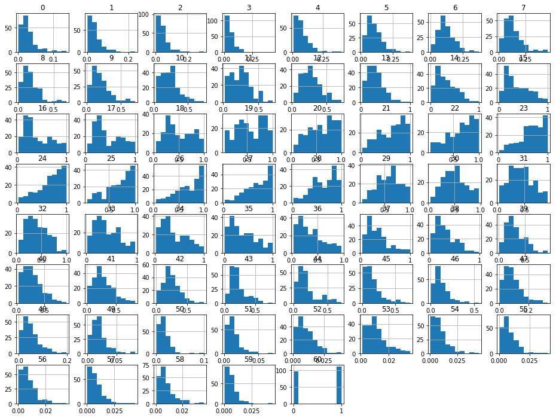

```python
# Histograms
df.hist(figsize=(16,12));
```

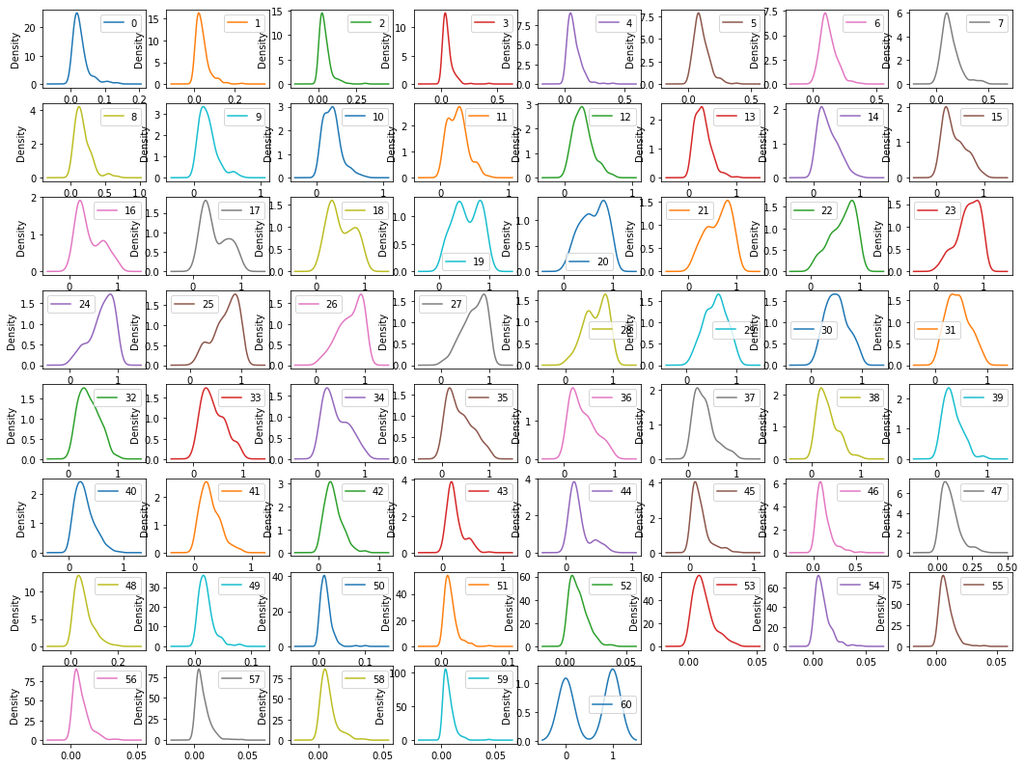

```python
# Density plots
df.plot(kind='density', subplots=True, layout=(8,8), sharex=False, figsize=(18, 14));
```

Many of the attributes have a skewed distribution. A power transform like a Box-Cox transform that can correct for the skew in distributions might be useful.

## Multivariate plots

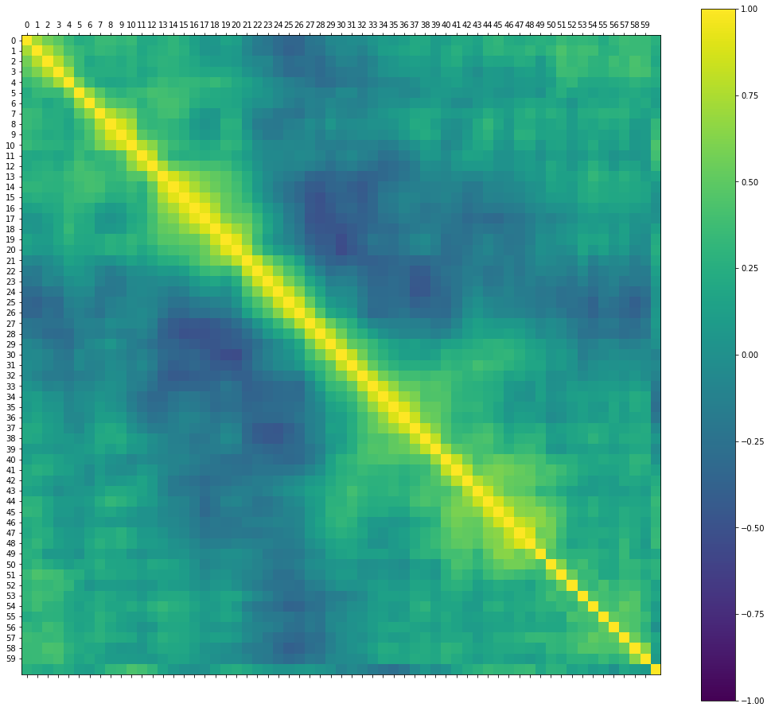

```python
correlations = df.corr()

# Plot correlation matrix
fig = plt.figure(figsize=(18,16))
ax = fig.add_subplot(111)
cax = ax.matshow(correlations, vmin=-1, vmax=1, interpolation='none')
fig.colorbar(cax)
ticks = np.arange(0, 60, 1)
ax.set_xticks(ticks)
ax.set_yticks(ticks)
plt.show()
```

It looks like there is also some structure in the order of the attributes. The yellow/light green around the diagonal suggests that attributes that are next to each other are generally more correlated with each other. The blue patches also suggest some moderate negative correlation the further attributes are away from each other in the ordering. This makes sense if the order of the attributes refers to the angle of sensors for the sonar chirp.

# Test dataset

To confirm the accuracy of our final model. It is a smoke test that we can use to see if we messed up and to give us confidence on our estimates of accuracy on unseen data. We will use 80% of the dataset for modeling and hold back 20% for validation.

```python
# Separate data into training and validation datasets
arr = df.values
X = arr[:,0:60]
y = arr[:,60]
test_size = 0.2
seed = 7
X_train, X_test, Y_train, Y_test = train_test_split(X, y, test_size=test_size, random_state=seed)
```

# Algorithms evaluation

The dataset is not too small. We will evaluate algorithms using the accuracy metric. Accuracy will give a gross idea of how wrong all predictions are (100 is perfect). In general accuracy may not be the best performance metric but this dataset is well balanced so it should be fine in this case.

```
LR: 76.94852941176471 (10.05102950966478)
LDA: 74.63235294117648 (11.785367885381074)
KNN: 80.80882352941175 (6.750704820308338)
CART: 73.56617647058823 (12.508053201685454)
NB: 64.88970588235294 (14.18684214516758)
SVM: 72.24264705882352 (9.768971096296516)
```

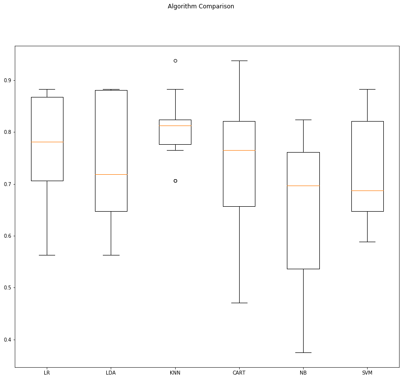

```python
# The baseline

# Test options and evaluation metric
num_folds = 10
seed = 7
scoring = 'accuracy'

# Spot-Check Algorithms
models = []
models.append(('LR', LogisticRegression(solver='lbfgs', max_iter=200, multi_class='ovr')))
models.append(('LDA', LinearDiscriminantAnalysis()))
models.append(('KNN', KNeighborsClassifier()))
models.append(('CART', DecisionTreeClassifier()))
models.append(('NB', GaussianNB()))
models.append(('SVM', SVC(gamma='scale')))

def eval_algorithms(models, show_boxplots=True):
    # Evaluate each model in turn
    # Setup the test harness to use 10-fold cross validation
    results = []
    names = []
    for name, model in models:
        kfold = KFold(n_splits=10, random_state=seed)
        cv_results = cross_val_score(model, X_train, Y_train, cv=kfold, scoring=scoring)
        results.append(cv_results)
        names.append(name)
        #print("Estimated accuracy of {} with the mean of {} and std. dev. {}".format(name, cv_results.mean()*100.0, cv_results.std()*100.0))
        print("{}: {} ({})".format(name, cv_results.mean()*100.0, cv_results.std()*100.0))

    if show_boxplots:
        # Create a plot of the model evaluation results to compae the spread
        # and the estimated mean accuracy of each model
        fig = plt.figure(figsize=(14,12))
        fig.suptitle('Algorithm Comparison')
        ax = fig.add_subplot(111)
        plt.boxplot(results)
        ax.set_xticklabels(names)
        plt.show()

eval_algorithms(models)
```

Running the example provides the output below. The results suggest That both Logistic Regression and k-Nearest Neighbors may be worth further study.

It is possible that the varied distribution of the attributes is having an effect on the accuracy of algorithms such as SVM. In the next section we will repeat this spot-check with a standardized copy of the training dataset (standardization = each attriobute has a mean value of zero and a standard deviation of 1). To avaid data leakage when we transform, we use pipelines.

## Standardization

This is where the data is transformed such that each attribute has a mean value of zero and a standard deviation of one. We also need to avoid data leakage when we transform the data. A good way to avoid leakage is to use pipelines that standardize the data and build the model for each fold in the cross validation test harness. That way we can get a fair estimation of how each model with standardized data might perform on unseen data.

```
ScaledLR: 74.04411764705883 (9.466751140841813)
ScaledLDA: 74.63235294117648 (11.785367885381074)
ScaledKNN: 82.57352941176471 (5.451103821426657)
ScaledCART: 68.16176470588235 (11.56914671483349)
ScaledNB: 64.88970588235294 (14.18684214516758)
ScaledSVM: 83.63970588235293 (8.869747214968386)
```

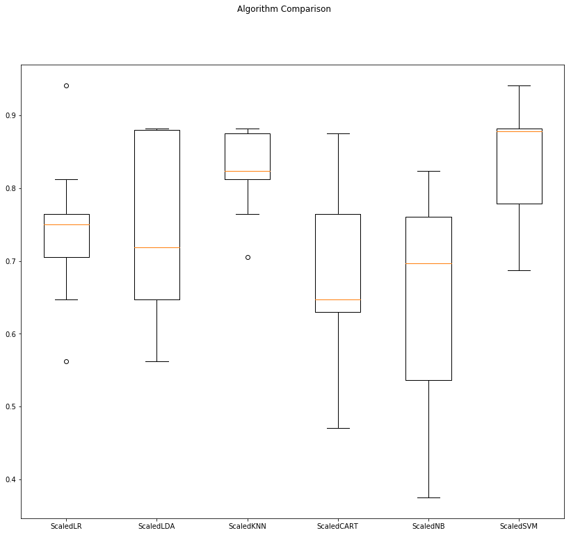

```python
# Standardize the dataset
pipelines = []
pipelines.append(('ScaledLR', Pipeline([('Scaler', StandardScaler()),('LR', LogisticRegression(solver='lbfgs', max_iter=200, multi_class='ovr'))])))
pipelines.append(('ScaledLDA', Pipeline([('Scaler', StandardScaler()),('LDA', LinearDiscriminantAnalysis())])))
pipelines.append(('ScaledKNN', Pipeline([('Scaler', StandardScaler()),('KNN', KNeighborsClassifier())])))
pipelines.append(('ScaledCART', Pipeline([('Scaler', StandardScaler()),('CART', DecisionTreeClassifier())])))
pipelines.append(('ScaledNB', Pipeline([('Scaler', StandardScaler()),('NB', GaussianNB())])))
pipelines.append(('ScaledSVM', Pipeline([('Scaler', StandardScaler()),('SVM', SVC(gamma='scale'))])))

eval_algorithms(pipelines)
```

We can see that KNN is still doing well, even better than before. We can also see that the standardization of the data has lifted the skill of SVM to be the most accurate algorithm tested so far.

# Improve results with algorithm tuning

## KNN Tuning

We can start off by tuning the number of neighbors for KNN. The default number of neighbors is 5. Below we try all odd values of k from 1 to 21, covering the default value of 5. Each k value is evaluated using 10-fold cross validation on the training standardized dataset.

```python
# KNN Algorithm tuning
scaler = StandardScaler().fit(X_train)
rescaledX = scaler.transform(X_train)
k_values = np.array([1,3,5,7,9,11,13,15,17,19,21])
param_grid = dict(n_neighbors=k_values)
model = KNeighborsClassifier()
kfold = KFold(n_splits=num_folds, random_state=seed)
grid = GridSearchCV(estimator=model, param_grid=param_grid, scoring=scoring, cv=kfold, iid=False)
grid_result = grid.fit(rescaledX, Y_train)

# Print results
print("Best: {} using {}".format(grid_result.best_score_, grid_result.best_params_))
means = grid_result.cv_results_['mean_test_score']
stds = grid_result.cv_results_['std_test_score']
params = grid_result.cv_results_['params']
for mean, stdev, param in zip(means, stds, params):
    print("{} ({}) with: {}".format(mean, stdev, param))
```

```
Best: 0.85 using {'n_neighbors': 1}
0.85 (0.05968577609876672) with: {'n_neighbors': 1}
0.8371323529411765 (0.06601389343386418) with: {'n_neighbors': 3}
0.8375 (0.03737725007982011) with: {'n_neighbors': 5}
0.7639705882352941 (0.0893737825672642) with: {'n_neighbors': 7}
0.7514705882352941 (0.08705087404087493) with: {'n_neighbors': 9}
0.7334558823529411 (0.104830998652816) with: {'n_neighbors': 11}
0.7330882352941176 (0.10580573208090603) with: {'n_neighbors': 13}
0.7279411764705882 (0.07614821756326462) with: {'n_neighbors': 15}
0.7099264705882353 (0.07928656388570995) with: {'n_neighbors': 17}
0.7220588235294118 (0.08508785913176035) with: {'n_neighbors': 19}
0.7102941176470587 (0.10950452661639593) with: {'n_neighbors': 21}
```

We can see that the optimal configuration is K=1.

## SVM Tunning

We can tune two key parameters of the SVM algorithm, the value of C (how much to relax the margin) and the type of kernel. The default for SVM (the SVC class) is to use the Radial Basis Function (RBF) kernel with a C value set to 1.0. Like with KNN, we will perform a grid search using 10-fold cross validation with a standardized copy of the training dataset. We will try a number of simpler kernel types and C values with less bias and more bias (less than and more than 1.0 respectively).

```python
# Tune scaled SVM
scaler = StandardScaler().fit(X_train)
rescaledX = scaler.transform(X_train)
c_values = [0.1, 0.3, 0.5, 0.7, 0.9, 1.0, 1.3, 1.5, 1.7, 2.0]
kernel_values = ['linear', 'poly', 'rbf', 'sigmoid']
param_grid = dict(C=c_values, kernel=kernel_values)
model = SVC(gamma='auto')
kfold = KFold(n_splits=num_folds, random_state=seed)
grid = GridSearchCV(estimator=model, param_grid=param_grid, scoring=scoring, cv=kfold, iid=False)
grid_result = grid.fit(rescaledX, Y_train)

# Print results
print("Best: {} using {}".format(grid_result.best_score_, grid_result.best_params_))
means = grid_result.cv_results_['mean_test_score']
stds = grid_result.cv_results_['std_test_score']
params = grid_result.cv_results_['params']
for mean, stdev, param in zip(means, stds, params):
    print("{} ({}) with: {}".format(mean, stdev, param))
```

```
Best: 0.8661764705882353 using {'C': 1.5, 'kernel': 'rbf'}
0.7584558823529413 (0.09948301158200631) with: {'C': 0.1, 'kernel': 'linear'}
0.5294117647058824 (0.11882453042676783) with: {'C': 0.1, 'kernel': 'poly'}
0.5731617647058824 (0.1309303654500583) with: {'C': 0.1, 'kernel': 'rbf'}
0.7040441176470589 (0.06693297175243644) with: {'C': 0.1, 'kernel': 'sigmoid'}
0.7463235294117647 (0.10950699524194979) with: {'C': 0.3, 'kernel': 'linear'}
0.6426470588235295 (0.13218739646981145) with: {'C': 0.3, 'kernel': 'poly'}
0.7658088235294118 (0.09169164818973898) with: {'C': 0.3, 'kernel': 'rbf'}
0.7349264705882353 (0.054566800193808336) with: {'C': 0.3, 'kernel': 'sigmoid'}
0.7400735294117646 (0.08263557723261496) with: {'C': 0.5, 'kernel': 'linear'}
0.6801470588235293 (0.09859523701095135) with: {'C': 0.5, 'kernel': 'poly'}
0.788235294117647 (0.06418995518008062) with: {'C': 0.5, 'kernel': 'rbf'}
0.7466911764705882 (0.05874190108352445) with: {'C': 0.5, 'kernel': 'sigmoid'}
0.7466911764705882 (0.0841975980083792) with: {'C': 0.7, 'kernel': 'linear'}
0.7400735294117646 (0.1279078937439239) with: {'C': 0.7, 'kernel': 'poly'}
0.8125 (0.0855125246295074) with: {'C': 0.7, 'kernel': 'rbf'}
0.7588235294117647 (0.06147955887260048) with: {'C': 0.7, 'kernel': 'sigmoid'}
0.7588235294117647 (0.0965197821127894) with: {'C': 0.9, 'kernel': 'linear'}
0.7702205882352942 (0.10251025879120317) with: {'C': 0.9, 'kernel': 'poly'}
0.8363970588235293 (0.08869747214968386) with: {'C': 0.9, 'kernel': 'rbf'}
0.7588235294117647 (0.06753507354826489) with: {'C': 0.9, 'kernel': 'sigmoid'}
0.7525735294117647 (0.09888339070211641) with: {'C': 1.0, 'kernel': 'linear'}
0.7882352941176471 (0.10841786472257907) with: {'C': 1.0, 'kernel': 'poly'}
0.8363970588235293 (0.08869747214968386) with: {'C': 1.0, 'kernel': 'rbf'}
0.7466911764705882 (0.07670442894915014) with: {'C': 1.0, 'kernel': 'sigmoid'}
0.7698529411764706 (0.10608640468747901) with: {'C': 1.3, 'kernel': 'linear'}
0.8183823529411764 (0.10715130136439335) with: {'C': 1.3, 'kernel': 'poly'}
0.8481617647058822 (0.08041391757735976) with: {'C': 1.3, 'kernel': 'rbf'}
0.7099264705882353 (0.0875810610679356) with: {'C': 1.3, 'kernel': 'sigmoid'}
0.7580882352941176 (0.09202639910095302) with: {'C': 1.5, 'kernel': 'linear'}
0.8301470588235293 (0.11025489498662683) with: {'C': 1.5, 'kernel': 'poly'}
0.8661764705882353 (0.0914577019483583) with: {'C': 1.5, 'kernel': 'rbf'}
0.7404411764705883 (0.06276328627315675) with: {'C': 1.5, 'kernel': 'sigmoid'}
0.7463235294117647 (0.09041427146434937) with: {'C': 1.7, 'kernel': 'linear'}
0.8305147058823529 (0.11670637248622173) with: {'C': 1.7, 'kernel': 'poly'}
0.8602941176470589 (0.08828123803855142) with: {'C': 1.7, 'kernel': 'rbf'}
0.7161764705882353 (0.09998107519887887) with: {'C': 1.7, 'kernel': 'sigmoid'}
0.7584558823529411 (0.09406377709245813) with: {'C': 2.0, 'kernel': 'linear'}
0.8308823529411764 (0.10895014494274426) with: {'C': 2.0, 'kernel': 'poly'}
0.8661764705882353 (0.09516592230502519) with: {'C': 2.0, 'kernel': 'rbf'}
0.7216911764705882 (0.10057751168328524) with: {'C': 2.0, 'kernel': 'sigmoid'}
```

We can see the most accurate configuration was SVM with an RBF kernel and a C value of 1.5. The accuracy 86.61% is seemingly better than what KNN could achieve (85%).

# Improve results with ensemble methods

In this section we will evaluate four different ensemble machine learning algorithms, two boosting and two bagging methods:

- Boosting Methods: AdaBoost (AB) and Gradient Boosting (GBM).
- Bagging Methods: Random Forests (RF) and Extra Trees (ET).

We will use the same test harness as before, 10-fold cross validation. No data standardization is used in this case because all four ensemble algorithms are based on decision trees that are less sensitive to data distributions.

```
AB: 81.98529411764707 (5.829264110434879)
GBM: 83.52941176470587 (12.97518092626088)
RF: 82.46323529411764 (8.912010407212836)
ET: 88.45588235294117 (8.497658948937453)
```

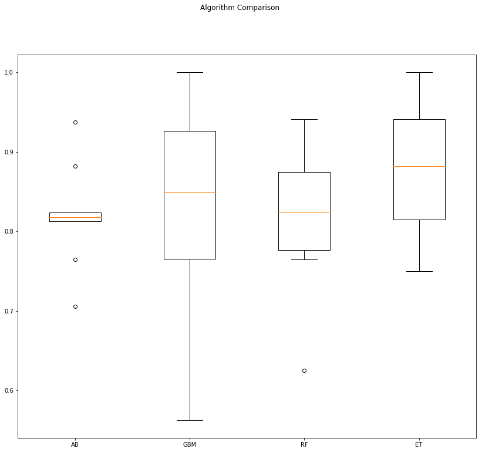

```python
# Ensembles
ensembles = []
ensembles.append(('AB', AdaBoostClassifier()))
ensembles.append(('GBM', GradientBoostingClassifier()))
ensembles.append(('RF', RandomForestClassifier(n_estimators=100)))
ensembles.append(('ET', ExtraTreesClassifier(n_estimators=100)))

eval_algorithms(ensembles)
```

# Finalize model

The SVM showed the most promise as a low complexity and stable model for this problem. In this section we will finalize the model by training it on the entire training dataset and make predictions for the hold-out validation dataset to confirm our findings. A part of the findings was that SVM performs better when the dataset is standardized so that all attributes have a mean value of zero and a standard deviation of one. We can calculate this from the entire training dataset and apply the same transform to the input attributes from the validation dataset.

```python
# Prepare the model
scaler = StandardScaler().fit(X_train)
rescaledX = scaler.transform(X_train)
clf = SVC(C=1.5, kernel='rbf', gamma='auto')
clf.fit(rescaledX, Y_train)

# Estimate accuracy on test dataset
rescaledTestX = scaler.transform(X_test)
pred = clf.predict(rescaledTestX)

print('Accuracy score: {}'.format(accuracy_score(Y_test, pred)))
print('\nConfusion matrix:\n {}'.format(confusion_matrix(Y_test, pred)))
print('\nClassification report:\n {}'.format(classification_report(Y_test, pred)))
```

```
Accuracy score: 0.8571428571428571

Confusion matrix:
 [[13  2]
 [ 4 23]]

Classification report:
               precision    recall  f1-score   support

         0.0       0.76      0.87      0.81        15
         1.0       0.92      0.85      0.88        27

   micro avg       0.86      0.86      0.86        42
   macro avg       0.84      0.86      0.85        42
weighted avg       0.86      0.86      0.86        42
```

We can see that we achieve an accuracy of nearly 86% on the held-out validation dataset. A score that matches closely to our expectations estimated above during the tuning of SVM.

# Save results

```python
# Save the model to disk
filename = 'finalized_model.sav'
dump(clf, open(filename, 'wb'))

# Some time later...
# Load the model from disk
loaded_clf = load(open(filename, 'rb'))

# The data must be standardized as in original model training
result = loaded_clf.score(rescaledTestX, Y_test)
print(result)
```

```
0.8571428571428571
```